# 🧠 Deteksi Anomali Ekonomi Makro — Autoencoder

**Early Warning System Krisis Ekonomi menggunakan Autoencoder (Deep Learning)**

Notebook ini mengimplementasikan pendekatan **Autoencoder** untuk mendeteksi anomali pada indikator ekonomi makro sebagai sistem peringatan dini (*Early Warning System*) krisis ekonomi.

**Metodologi:**

- Arsitektur: Encoder → Bottleneck → Decoder (kompresi non-linear)
- Threshold: Persentil ke-92 dari *reconstruction error*
- Evaluasi: Precision, Recall, F1-Score terhadap *ground truth* krisis historis
- Interpretasi: Feature importance berbasis *mean reconstruction error difference*

**Dataset:** 14 indikator makroekonomi, 49 negara, periode 1990–2024 (World Bank Open Data)  
**Disusun oleh:** Deka

## 1. Instalasi & Import Library

```
TensorFlow version: 2.19.0
GPU available: False
```

## 2. Load & Eksplorasi Data

```
Shape dataset: (1714, 17)
Jumlah negara: 49
Rentang tahun: 1990 – 2024

Distribusi crisis_label:
crisis_label
0    1385
1     329
Name: count, dtype: int64

Persentase krisis: 19.19%
```

|  | economy | year | GDP_Growth | GDP_PerCapita_Growth | Inflation_CPI | Total_Reserves | Unemployment | Current_Account_GDP | Trade_GDP | FDI_Inflows_GDP | Exports_GDP | Imports_GDP | Gross_Savings_GDP | Exchange_Rate | Manufacturing_Value | Investment_GDP | crisis_label |
| --- | --- | --- | --- | --- | --- | --- | --- | --- | --- | --- | --- | --- | --- | --- | --- | --- | --- |
| 0 | ARE | 1990 | 2.690913 | 2.607447 | -0.035597 | -0.349079 | -1.105892 | 2.12939 | 0.234573 | -0.486899 | 0.326385 | 0.123081 | 1.10385 | -0.224663 | -1.589531 | -0.270213 | 0 |
| 1 | ARE | 1991 | -0.638363 | -1.838101 | -0.035597 | -0.347005 | -1.105892 | 2.12939 | 0.234573 | -0.448764 | 0.326385 | 0.123081 | 1.10385 | -0.224663 | -1.601884 | -0.270213 | 0 |
| 2 | ARE | 1992 | 0.032110 | -1.108947 | -0.035597 | -0.346099 | -1.087378 | 2.12939 | 0.234573 | -0.422930 | 0.326385 | 0.123081 | 1.10385 | -0.224663 | -1.573871 | -0.270213 | 0 |
| 3 | ARE | 1993 | -0.530135 | -1.574741 | -0.035597 | -0.344897 | -1.047336 | 2.12939 | 0.234573 | -0.356948 | 0.326385 | 0.123081 | 1.10385 | -0.224663 | -1.528502 | -0.270213 | 0 |
| 4 | ARE | 1994 | 0.990307 | -0.018863 | -0.035597 | -0.343393 | -1.061760 | 2.12939 | 0.234573 | -0.441240 | 0.326385 | 0.123081 | 1.10385 | -0.224663 | -1.747591 | -0.270213 | 0 |

```
Jumlah fitur: 14
Missing values per fitur:
GDP_Growth              0
GDP_PerCapita_Growth    0
Inflation_CPI           0
Total_Reserves          0
Unemployment            0
Current_Account_GDP     0
Trade_GDP               0
FDI_Inflows_GDP         0
Exports_GDP             0
Imports_GDP             0
Gross_Savings_GDP       0
Exchange_Rate           0
Manufacturing_Value     0
Investment_GDP          0
dtype: int64

Statistik deskriptif (data sudah ter-standardisasi z-score):
```

|  | GDP_Growth | GDP_PerCapita_Growth | Inflation_CPI | Total_Reserves | Unemployment | Current_Account_GDP | Trade_GDP | FDI_Inflows_GDP | Exports_GDP | Imports_GDP | Gross_Savings_GDP | Exchange_Rate | Manufacturing_Value | Investment_GDP |
| --- | --- | --- | --- | --- | --- | --- | --- | --- | --- | --- | --- | --- | --- | --- |
| count | 1714.000 | 1714.000 | 1714.000 | 1714.000 | 1714.000 | 1714.000 | 1714.000 | 1714.000 | 1714.000 | 1714.000 | 1714.000 | 1714.000 | 1714.000 | 1714.000 |
| mean | -0.002 | -0.001 | -0.035 | -0.003 | -0.004 | 0.001 | -0.003 | -0.005 | -0.003 | -0.002 | -0.000 | -0.002 | -0.001 | -0.002 |
| std | 0.977 | 0.982 | 0.268 | 0.969 | 0.982 | 0.980 | 0.985 | 0.852 | 0.985 | 0.985 | 0.996 | 0.983 | 0.996 | 0.989 |
| min | -3.815 | -3.711 | -0.100 | -0.360 | -1.329 | -2.310 | -1.058 | -3.011 | -1.016 | -1.120 | -2.163 | -0.226 | -1.915 | -1.987 |
| 25% | -0.477 | -0.429 | -0.084 | -0.322 | -0.654 | -0.615 | -0.578 | -0.342 | -0.581 | -0.591 | -0.729 | -0.226 | -0.749 | -0.635 |
| 50% | 0.005 | 0.012 | -0.077 | -0.259 | -0.261 | -0.178 | -0.303 | -0.185 | -0.310 | -0.292 | -0.157 | -0.224 | -0.090 | -0.150 |
| 75% | 0.561 | 0.580 | -0.058 | -0.095 | 0.360 | 0.368 | 0.186 | 0.046 | 0.200 | 0.212 | 0.612 | -0.205 | 0.559 | 0.425 |
| max | 2.691 | 2.758 | 3.206 | 8.628 | 4.312 | 3.879 | 5.122 | 5.938 | 5.054 | 5.143 | 3.072 | 7.330 | 2.674 | 3.378 |

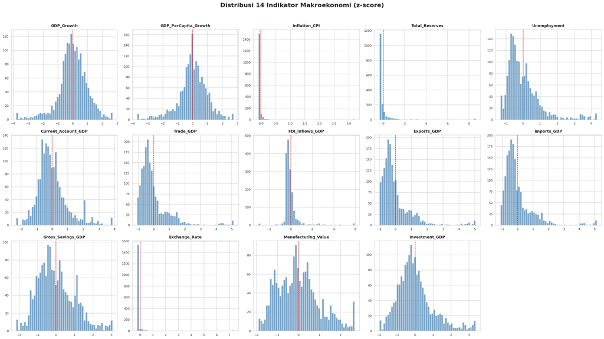

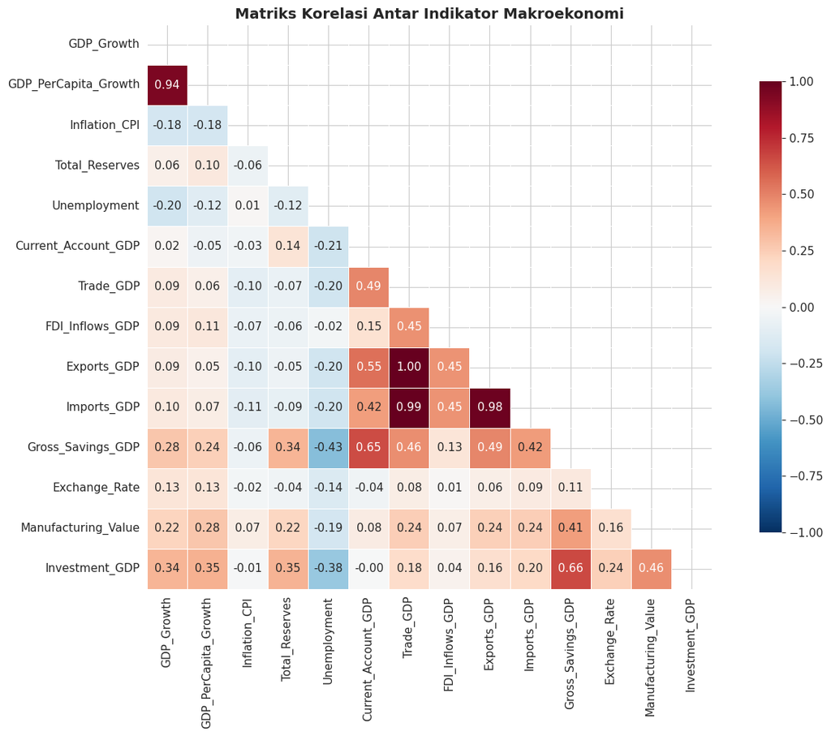

## 3. Persiapan Data untuk Autoencoder

```
Shape fitur (X): (1714, 14)
Shape label (y): (1714,)
Jumlah krisis (label=1): 329 (19.2%)
Jumlah normal (label=0): 1385 (80.8%)
```

```
Training set  : (1371, 14)
Validation set: (343, 14)
```

## 4. Arsitektur Autoencoder

Autoencoder diracik dengan susunan **Encoder → Bottleneck → Decoder** sebagaimana dirancang pada laporan:

- **Encoder**: Memampatkan 14 dimensi fitur melalui lapisan-lapisan yang semakin menyempit
- **Bottleneck**: Representasi laten terkompres (dimensi rendah)
- **Decoder**: Merekonstruksi data kembali ke 14 dimensi asli

Data perekonomian dengan **reconstruction error** tertinggi (melewati threshold persentil ke-92) diklasifikasikan sebagai **anomali/krisis**.

```
Model: "Autoencoder_EWS"
```

```
┏━━━━━━━━━━━━━━━━━━━━━━━━━━━━━━━━━┳━━━━━━━━━━━━━━━━━━━━━━━━┳━━━━━━━━━━━━━━━┓
┃ Layer (type)                    ┃ Output Shape           ┃       Param # ┃
┡━━━━━━━━━━━━━━━━━━━━━━━━━━━━━━━━━╇━━━━━━━━━━━━━━━━━━━━━━━━╇━━━━━━━━━━━━━━━┩
│ input (InputLayer)              │ (None, 14)             │             0 │
├─────────────────────────────────┼────────────────────────┼───────────────┤
│ encoder_1 (Dense)               │ (None, 32)             │           480 │
├─────────────────────────────────┼────────────────────────┼───────────────┤
│ bn_enc_1 (BatchNormalization)   │ (None, 32)             │           128 │
├─────────────────────────────────┼────────────────────────┼───────────────┤
│ lrelu_enc_1 (LeakyReLU)         │ (None, 32)             │             0 │
├─────────────────────────────────┼────────────────────────┼───────────────┤
│ dropout_enc_1 (Dropout)         │ (None, 32)             │             0 │
├─────────────────────────────────┼────────────────────────┼───────────────┤
│ encoder_2 (Dense)               │ (None, 16)             │           528 │
├─────────────────────────────────┼────────────────────────┼───────────────┤
│ bn_enc_2 (BatchNormalization)   │ (None, 16)             │            64 │
├─────────────────────────────────┼────────────────────────┼───────────────┤
│ lrelu_enc_2 (LeakyReLU)         │ (None, 16)             │             0 │
├─────────────────────────────────┼────────────────────────┼───────────────┤
│ dropout_enc_2 (Dropout)         │ (None, 16)             │             0 │
├─────────────────────────────────┼────────────────────────┼───────────────┤
│ bottleneck (Dense)              │ (None, 6)              │           102 │
├─────────────────────────────────┼────────────────────────┼───────────────┤
│ decoder_1 (Dense)               │ (None, 16)             │           112 │
├─────────────────────────────────┼────────────────────────┼───────────────┤
│ bn_dec_1 (BatchNormalization)   │ (None, 16)             │            64 │
├─────────────────────────────────┼────────────────────────┼───────────────┤
│ lrelu_dec_1 (LeakyReLU)         │ (None, 16)             │             0 │
├─────────────────────────────────┼────────────────────────┼───────────────┤
│ dropout_dec_1 (Dropout)         │ (None, 16)             │             0 │
├─────────────────────────────────┼────────────────────────┼───────────────┤
│ decoder_2 (Dense)               │ (None, 32)             │           544 │
├─────────────────────────────────┼────────────────────────┼───────────────┤
│ bn_dec_2 (BatchNormalization)   │ (None, 32)             │           128 │
├─────────────────────────────────┼────────────────────────┼───────────────┤
│ lrelu_dec_2 (LeakyReLU)         │ (None, 32)             │             0 │
├─────────────────────────────────┼────────────────────────┼───────────────┤
│ dropout_dec_2 (Dropout)         │ (None, 32)             │             0 │
├─────────────────────────────────┼────────────────────────┼───────────────┤
│ output (Dense)                  │ (None, 14)             │           462 │
└─────────────────────────────────┴────────────────────────┴───────────────┘
```

```
 Total params: 2,612 (10.20 KB)
```

```
 Trainable params: 2,420 (9.45 KB)
```

```
 Non-trainable params: 192 (768.00 B)
```

```
============================================================
  ARSITEKTUR AUTOENCODER — EARLY WARNING SYSTEM
============================================================

  Input (14 fitur makroekonomi)
       │
  ┌────▼────┐
  │ Dense 32│ + BatchNorm + LeakyReLU + Dropout(0.2)
  └────┬────┘
       │        ENCODER
  ┌────▼────┐
  │ Dense 16│ + BatchNorm + LeakyReLU + Dropout(0.2)
  └────┬────┘
       │
  ╔════▼════╗
  ║Dense  6 ║  ← BOTTLENECK (representasi laten)
  ╚════╤════╝
       │
  ┌────▼────┐
  │ Dense 16│ + BatchNorm + LeakyReLU + Dropout(0.2)
  └────┬────┘
       │        DECODER
  ┌────▼────┐
  │ Dense 32│ + BatchNorm + LeakyReLU + Dropout(0.2)
  └────┬────┘
       │
  ┌────▼────┐
  │Dense  14│  ← Output (rekonstruksi)
  └─────────┘

  Loss Function : Mean Squared Error (MSE)
  Optimizer     : Adam (lr=0.001)
  Bottleneck    : 6 dimensi (rasio kompresi = 14/6 = 2.3x)
```

## 5. Training Autoencoder

```
🚀 Memulai training Autoencoder...

43/43 ━━━━━━━━━━━━━━━━━━━━ 4s 9ms/step - loss: 1.4274 - val_loss: 0.9616 - learning_rate: 0.0010
43/43 ━━━━━━━━━━━━━━━━━━━━ 0s 4ms/step - loss: 1.0425 - val_loss: 0.9096 - learning_rate: 0.0010
43/43 ━━━━━━━━━━━━━━━━━━━━ 0s 3ms/step - loss: 0.8729 - val_loss: 0.8215 - learning_rate: 0.0010
43/43 ━━━━━━━━━━━━━━━━━━━━ 0s 3ms/step - loss: 0.7883 - val_loss: 0.7175 - learning_rate: 0.0010
43/43 ━━━━━━━━━━━━━━━━━━━━ 0s 4ms/step - loss: 0.7204 - val_loss: 0.6168 - learning_rate: 0.0010
43/43 ━━━━━━━━━━━━━━━━━━━━ 0s 5ms/step - loss: 0.6789 - val_loss: 0.5410 - learning_rate: 0.0010
43/43 ━━━━━━━━━━━━━━━━━━━━ 0s 4ms/step - loss: 0.6424 - val_loss: 0.4961 - learning_rate: 0.0010
43/43 ━━━━━━━━━━━━━━━━━━━━ 0s 4ms/step - loss: 0.6256 - val_loss: 0.4680 - learning_rate: 0.0010
43/43 ━━━━━━━━━━━━━━━━━━━━ 0s 4ms/step - loss: 0.6028 - val_loss: 0.4511 - learning_rate: 0.0010
43/43 ━━━━━━━━━━━━━━━━━━━━ 0s 5ms/step - loss: 0.5848 - val_loss: 0.4388 - learning_rate: 0.0010
43/43 ━━━━━━━━━━━━━━━━━━━━ 0s 5ms/step - loss: 0.5621 - val_loss: 0.4226 - learning_rate: 0.0010
43/43 ━━━━━━━━━━━━━━━━━━━━ 0s 4ms/step - loss: 0.5503 - val_loss: 0.4149 - learning_rate: 0.0010
43/43 ━━━━━━━━━━━━━━━━━━━━ 0s 4ms/step - loss: 0.5339 - val_loss: 0.4079 - learning_rate: 0.0010
43/43 ━━━━━━━━━━━━━━━━━━━━ 0s 4ms/step - loss: 0.5363 - val_loss: 0.4039 - learning_rate: 0.0010
43/43 ━━━━━━━━━━━━━━━━━━━━ 0s 4ms/step - loss: 0.5244 - val_loss: 0.3968 - learning_rate: 0.0010
43/43 ━━━━━━━━━━━━━━━━━━━━ 0s 4ms/step - loss: 0.5266 - val_loss: 0.3890 - learning_rate: 0.0010
43/43 ━━━━━━━━━━━━━━━━━━━━ 0s 4ms/step - loss: 0.5079 - val_loss: 0.3782 - learning_rate: 0.0010
43/43 ━━━━━━━━━━━━━━━━━━━━ 0s 4ms/step - loss: 0.5217 - val_loss: 0.3671 - learning_rate: 0.0010
43/43 ━━━━━━━━━━━━━━━━━━━━ 0s 4ms/step - loss: 0.5046 - val_loss: 0.3597 - learning_rate: 0.0010
43/43 ━━━━━━━━━━━━━━━━━━━━ 0s 5ms/step - loss: 0.4852 - val_loss: 0.3555 - learning_rate: 0.0010
43/43 ━━━━━━━━━━━━━━━━━━━━ 0s 4ms/step - loss: 0.4894 - val_loss: 0.3490 - learning_rate: 0.0010
43/43 ━━━━━━━━━━━━━━━━━━━━ 0s 5ms/step - loss: 0.4725 - val_loss: 0.3426 - learning_rate: 0.0010
43/43 ━━━━━━━━━━━━━━━━━━━━ 0s 5ms/step - loss: 0.4691 - val_loss: 0.3357 - learning_rate: 0.0010
43/43 ━━━━━━━━━━━━━━━━━━━━ 0s 3ms/step - loss: 0.4717 - val_loss: 0.3290 - learning_rate: 0.0010
43/43 ━━━━━━━━━━━━━━━━━━━━ 0s 4ms/step - loss: 0.4657 - val_loss: 0.3221 - learning_rate: 0.0010
43/43 ━━━━━━━━━━━━━━━━━━━━ 0s 4ms/step - loss: 0.4488 - val_loss: 0.3179 - learning_rate: 0.0010
43/43 ━━━━━━━━━━━━━━━━━━━━ 0s 4ms/step - loss: 0.4488 - val_loss: 0.3118 - learning_rate: 0.0010
43/43 ━━━━━━━━━━━━━━━━━━━━ 0s 4ms/step - loss: 0.4482 - val_loss: 0.3102 - learning_rate: 0.0010
43/43 ━━━━━━━━━━━━━━━━━━━━ 0s 4ms/step - loss: 0.4429 - val_loss: 0.3051 - learning_rate: 0.0010
43/43 ━━━━━━━━━━━━━━━━━━━━ 0s 5ms/step - loss: 0.4331 - val_loss: 0.3041 - learning_rate: 0.0010
43/43 ━━━━━━━━━━━━━━━━━━━━ 0s 4ms/step - loss: 0.4366 - val_loss: 0.2983 - learning_rate: 0.0010
43/43 ━━━━━━━━━━━━━━━━━━━━ 0s 5ms/step - loss: 0.4272 - val_loss: 0.2944 - learning_rate: 0.0010
43/43 ━━━━━━━━━━━━━━━━━━━━ 0s 4ms/step - loss: 0.4322 - val_loss: 0.2916 - learning_rate: 0.0010
43/43 ━━━━━━━━━━━━━━━━━━━━ 0s 4ms/step - loss: 0.4289 - val_loss: 0.2905 - learning_rate: 0.0010
43/43 ━━━━━━━━━━━━━━━━━━━━ 0s 4ms/step - loss: 0.4220 - val_loss: 0.2910 - learning_rate: 0.0010
43/43 ━━━━━━━━━━━━━━━━━━━━ 0s 3ms/step - loss: 0.4207 - val_loss: 0.2907 - learning_rate: 0.0010
43/43 ━━━━━━━━━━━━━━━━━━━━ 0s 5ms/step - loss: 0.4201 - val_loss: 0.2898 - learning_rate: 0.0010
43/43 ━━━━━━━━━━━━━━━━━━━━ 0s 4ms/step - loss: 0.4255 - val_loss: 0.2841 - learning_rate: 0.0010
```

[output cut: 161 more lines]

```
43/43 ━━━━━━━━━━━━━━━━━━━━ 0s 3ms/step - loss: 0.3051 - val_loss: 0.2065 - learning_rate: 6.2500e-05
43/43 ━━━━━━━━━━━━━━━━━━━━ 0s 3ms/step - loss: 0.3099 - val_loss: 0.2020 - learning_rate: 6.2500e-05
43/43 ━━━━━━━━━━━━━━━━━━━━ 0s 4ms/step - loss: 0.3183 - val_loss: 0.2003 - learning_rate: 6.2500e-05
43/43 ━━━━━━━━━━━━━━━━━━━━ 0s 6ms/step - loss: 0.3129 - val_loss: 0.2005 - learning_rate: 6.2500e-05
43/43 ━━━━━━━━━━━━━━━━━━━━ 0s 5ms/step - loss: 0.3184 - val_loss: 0.2010 - learning_rate: 6.2500e-05
43/43 ━━━━━━━━━━━━━━━━━━━━ 0s 4ms/step - loss: 0.3111 - val_loss: 0.2016 - learning_rate: 6.2500e-05
40/43 ━━━━━━━━━━━━━━━━━━━━ 0s 4ms/step - loss: 0.3194
Epoch 198: ReduceLROnPlateau reducing learning rate to 3.125000148429535e-05.
43/43 ━━━━━━━━━━━━━━━━━━━━ 0s 6ms/step - loss: 0.3126 - val_loss: 0.2026 - learning_rate: 6.2500e-05
Epoch 198: early stopping
Restoring model weights from the end of the best epoch: 178.

✅ Training selesai pada epoch 198
   Final Train Loss: 0.312638
   Final Val Loss  : 0.202603
```

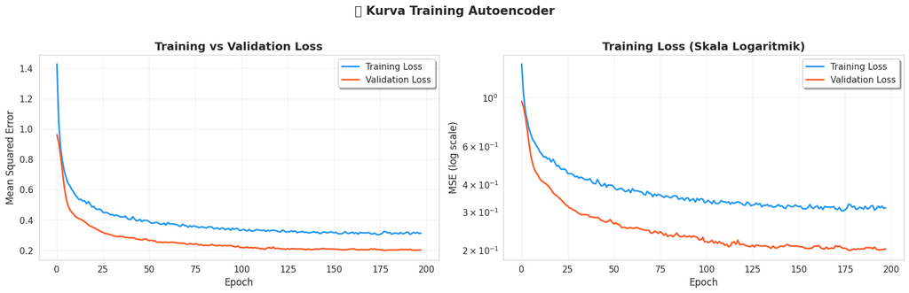

## 6. Deteksi Anomali — Reconstruction Error

```
📊 Statistik Reconstruction Error:
   Mean  : 0.197041
   Std   : 0.189058
   Min   : 0.004957
   Max   : 1.891616
   Median: 0.144153
```

```
🎯 Threshold (persentil ke-92): 0.453560

📋 Hasil Deteksi Anomali:
   Normal  (0): 1576 (91.9%)
   Anomali (1): 138 (8.1%)
```

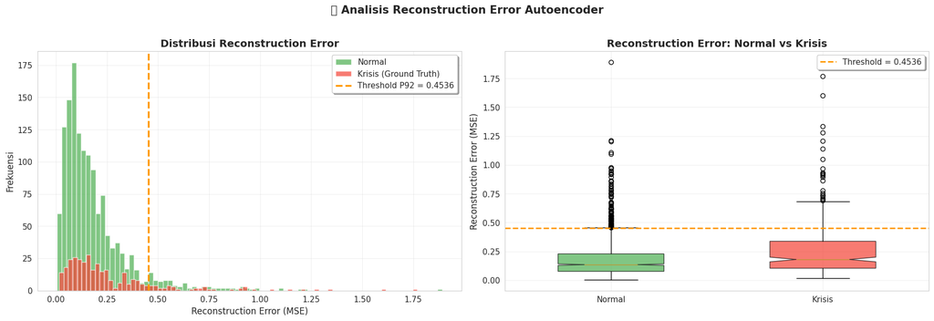

## 7. Evaluasi Model terhadap Ground Truth

```
============================================================
  📊 EVALUASI AUTOENCODER vs GROUND TRUTH KRISIS
============================================================

  Precision : 0.3261  — 32.6% anomali terdeteksi benar-benar krisis
  Recall    : 0.1368  — 13.7% krisis berhasil terdeteksi
  F1-Score  : 0.1927  — Harmonik keseimbangan Precision-Recall

  Threshold : Persentil ke-92 = 0.453560
============================================================

📋 Classification Report:
              precision    recall  f1-score   support

      Normal       0.82      0.93      0.87      1385
      Krisis       0.33      0.14      0.19       329

    accuracy                           0.78      1714
   macro avg       0.57      0.53      0.53      1714
weighted avg       0.73      0.78      0.74      1714
```

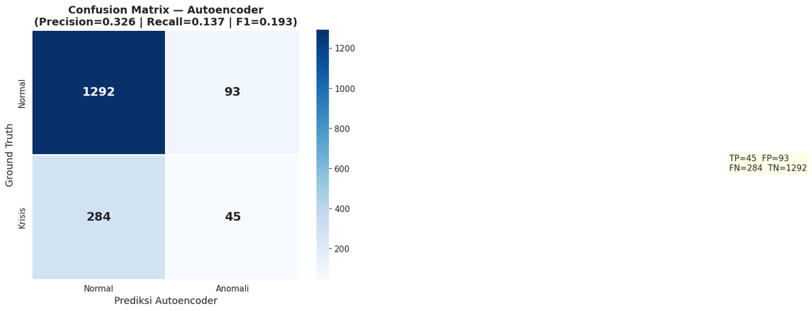

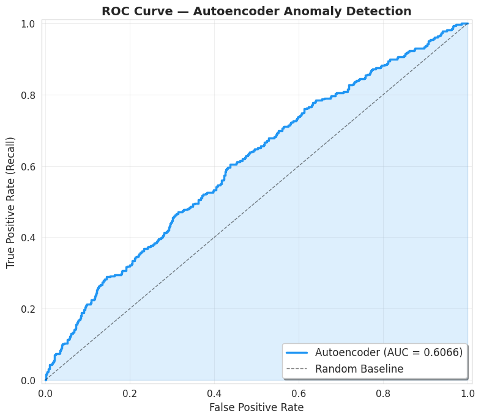

```
🎯 AUC-ROC Score: 0.6066
```

## 8. Analisis Deteksi per Krisis Historis

```
===========================================================================
  📋 ANALISIS DETEKSI PER KRISIS HISTORIS
===========================================================================

  🔸 Krisis Asia 1997-98
    Observasi  : 10
    Terdeteksi : 5/10 (50.0%)
    Avg Error  : 0.502938 (threshold: 0.453560)
    Negara     : IDN, KOR, MYS, THA

  🔸 Krisis Rusia 1998
    Observasi  : 1
    Terdeteksi : 0/1 (0.0%)
    Avg Error  : 0.133122 (threshold: 0.453560)

  🔸 Krisis Argentina 2001-02
    Observasi  : 2
    Terdeteksi : 1/2 (50.0%)
    Avg Error  : 0.457740 (threshold: 0.453560)
    Negara     : ARG

  🔸 Global Financial Crisis 2008-09
    Observasi  : 98
    Terdeteksi : 7/98 (7.1%)
    Avg Error  : 0.216832 (threshold: 0.453560)
    Negara     : ARE, BEL, HUN, IRL, ROU, SGP

  🔸 Krisis Utang Eropa 2010-12
    Observasi  : 15
    Terdeteksi : 1/15 (6.7%)
    Avg Error  : 0.247125 (threshold: 0.453560)
    Negara     : IRL

  🔸 Pandemi COVID-19 2020
    Observasi  : 49
    Terdeteksi : 9/49 (18.4%)
    Avg Error  : 0.325558 (threshold: 0.453560)
    Negara     : CHE, HUN, IDN, IRL, NLD, SGP, TUR, VNM, ZAF

===========================================================================
```

|  | Krisis | Total Observasi | Terdeteksi | Detection Rate (%) | Avg Recon Error |
| --- | --- | --- | --- | --- | --- |
| 0 | Krisis Asia 1997-98 | 10 | 5 | 50.0 | 0.502938 |
| 1 | Krisis Rusia 1998 | 1 | 0 | 0.0 | 0.133122 |
| 2 | Krisis Argentina 2001-02 | 2 | 1 | 50.0 | 0.457740 |
| 3 | Global Financial Crisis 2008-09 | 98 | 7 | 7.1 | 0.216832 |
| 4 | Krisis Utang Eropa 2010-12 | 15 | 1 | 6.7 | 0.247125 |
| 5 | Pandemi COVID-19 2020 | 49 | 9 | 18.4 | 0.325558 |

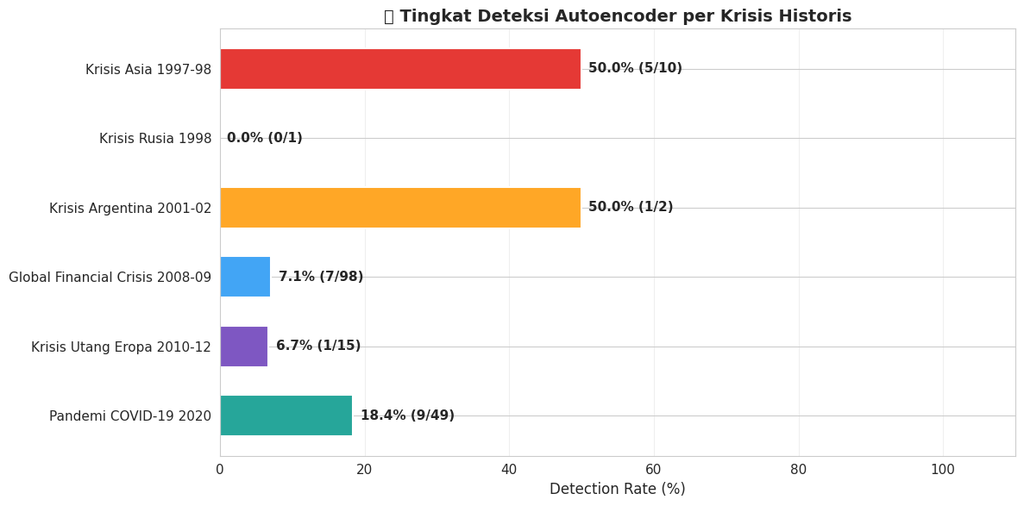

## 9. Reduksi Dimensi & Visualisasi

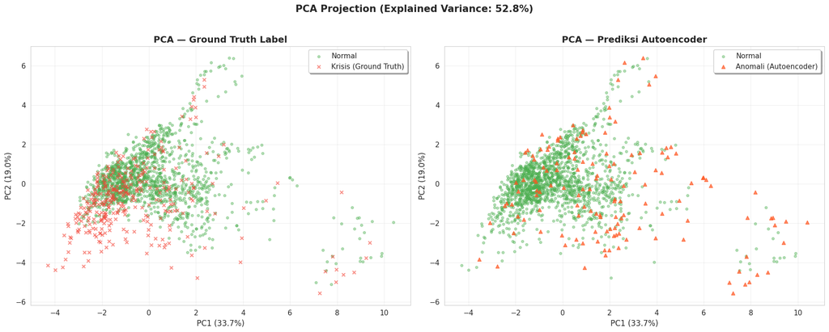

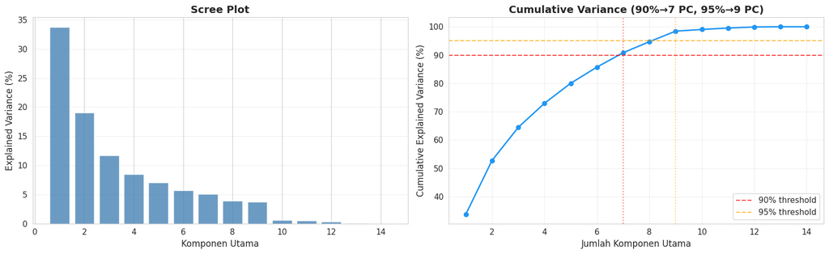

```
⏳ Menjalankan t-SNE (mungkin memakan waktu beberapa menit)...
✅ t-SNE selesai!
```

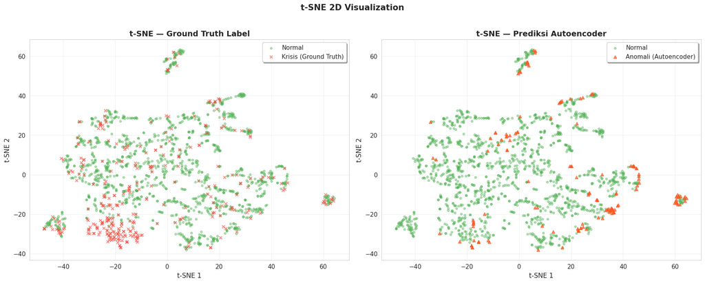

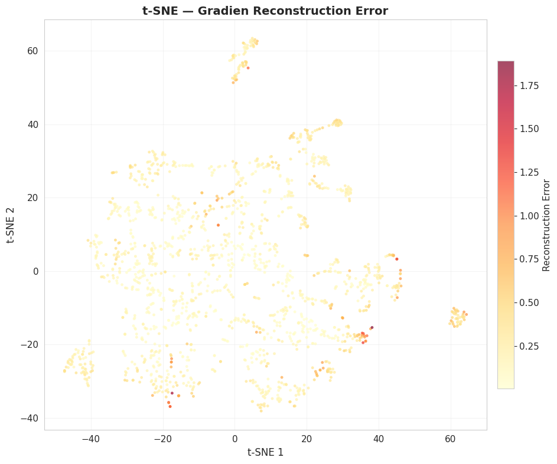

## 10. Feature Importance — Analisis Kontribusi Indikator

Mengidentifikasi variabel ekonomi makro mana yang paling berkontribusi terhadap deteksi anomali, menggunakan pendekatan **Mean Reconstruction Error Difference** per fitur.

```
📊 Feature Importance (berdasarkan Reconstruction Error Difference):
===========================================================================
```

|  | Feature | Error_Anomaly | Error_Normal | Error_Difference | Importance_Ratio |
| --- | --- | --- | --- | --- | --- |
| 0 | FDI_Inflows_GDP | 2.047934 | 0.118514 | 1.929419 | 17.280044 |
| 1 | GDP_PerCapita_Growth | 0.973869 | 0.134236 | 0.839632 | 7.254874 |
| 2 | GDP_Growth | 0.867038 | 0.138547 | 0.728492 | 6.258101 |
| 3 | Inflation_CPI | 0.731402 | 0.008990 | 0.722412 | 81.357345 |
| 4 | Investment_GDP | 0.988838 | 0.279251 | 0.709588 | 3.541042 |
| 5 | Current_Account_GDP | 0.868974 | 0.253916 | 0.615057 | 3.422283 |
| 6 | Manufacturing_Value | 0.812445 | 0.346240 | 0.466205 | 2.346479 |
| 7 | Imports_GDP | 0.414546 | 0.083901 | 0.330645 | 4.940905 |
| 8 | Trade_GDP | 0.344196 | 0.065238 | 0.278957 | 5.275959 |
| 9 | Exchange_Rate | 0.307564 | 0.050678 | 0.256886 | 6.068942 |
| 10 | Exports_GDP | 0.314564 | 0.060831 | 0.253733 | 5.171077 |
| 11 | Total_Reserves | 0.314353 | 0.127199 | 0.187154 | 2.471343 |
| 12 | Gross_Savings_GDP | 0.304374 | 0.191326 | 0.113047 | 1.590861 |
| 13 | Unemployment | 0.377195 | 0.294753 | 0.082442 | 1.279698 |

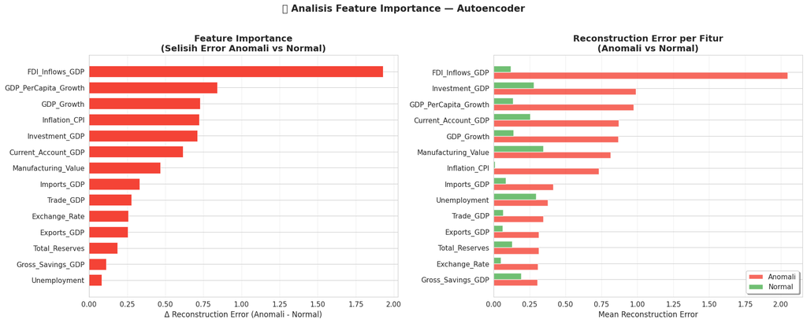

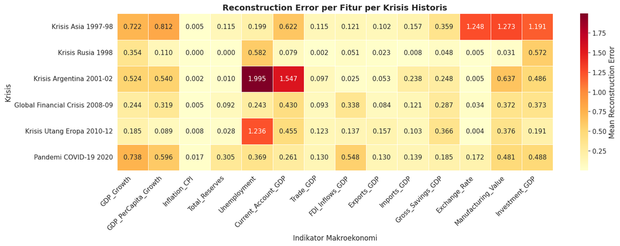

## 11. Timeline Anomali — Perspektif Temporal

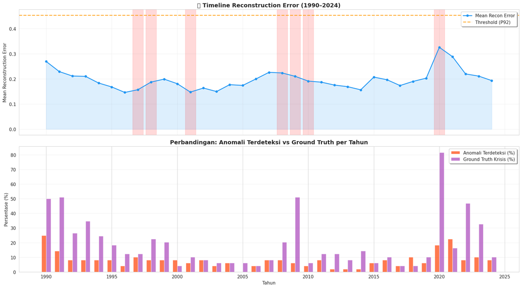

## 12. Top Anomali Terdeteksi

```
🔝 Top 30 Observasi dengan Reconstruction Error Tertinggi:
===========================================================================
```

|  | economy | year | reconstruction_error | anomaly_ae | crisis_label | Status |
| --- | --- | --- | --- | --- | --- | --- |
| 0 | IRL | 2015 | 1.891616 | 1 | 0 | ⚠️ False Positive |
| 1 | IDN | 1998 | 1.769980 | 1 | 1 | ✅ True Positive |
| 2 | IRL | 2019 | 1.599307 | 1 | 1 | ✅ True Positive |
| 3 | HUN | 2020 | 1.335914 | 1 | 1 | ✅ True Positive |
| 4 | RUS | 1992 | 1.281553 | 1 | 1 | ✅ True Positive |
| 5 | NLD | 2006 | 1.212206 | 1 | 0 | ⚠️ False Positive |
| 6 | RUS | 1991 | 1.205489 | 1 | 1 | ✅ True Positive |
| 7 | NLD | 2007 | 1.202216 | 1 | 0 | ⚠️ False Positive |
| 8 | IDN | 2020 | 1.140490 | 1 | 1 | ✅ True Positive |
| 9 | IRL | 2020 | 1.105883 | 1 | 0 | ⚠️ False Positive |
| 10 | HUN | 2019 | 1.093259 | 1 | 0 | ⚠️ False Positive |
| 11 | BRA | 1993 | 1.047876 | 1 | 1 | ✅ True Positive |
| 12 | BEL | 1999 | 0.978751 | 1 | 0 | ⚠️ False Positive |
| 13 | HUN | 2007 | 0.977002 | 1 | 0 | ⚠️ False Positive |
| 14 | BRA | 1992 | 0.965476 | 1 | 0 | ⚠️ False Positive |
| 15 | BRA | 1994 | 0.965430 | 1 | 1 | ✅ True Positive |
| 16 | SGP | 2021 | 0.947499 | 1 | 0 | ⚠️ False Positive |
| 17 | IRL | 2016 | 0.935680 | 1 | 0 | ⚠️ False Positive |
| 18 | IRL | 2023 | 0.932128 | 1 | 1 | ✅ True Positive |
| 19 | RUS | 1993 | 0.926373 | 1 | 1 | ✅ True Positive |
| 20 | IRL | 2021 | 0.920799 | 1 | 0 | ⚠️ False Positive |
| 21 | SGP | 2010 | 0.920487 | 1 | 0 | ⚠️ False Positive |
| 22 | HUN | 2008 | 0.919799 | 1 | 0 | ⚠️ False Positive |
| 23 | ROU | 1990 | 0.917664 | 1 | 1 | ✅ True Positive |
| 24 | RUS | 1990 | 0.909364 | 1 | 1 | ✅ True Positive |
| 25 | NGA | 2002 | 0.893927 | 1 | 0 | ⚠️ False Positive |
| 26 | BRA | 1990 | 0.893060 | 1 | 1 | ✅ True Positive |
| 27 | PER | 1990 | 0.863623 | 1 | 1 | ✅ True Positive |
| 28 | NLD | 2015 | 0.861929 | 1 | 0 | ⚠️ False Positive |
| 29 | MYS | 1995 | 0.858242 | 1 | 0 | ⚠️ False Positive |

```
🌍 Negara dengan Anomali Terbanyak:
===========================================================================
```

| economy | anomaly_count | avg_error | years_detected |
| --- | --- | --- | --- |
| IRL | 18 | 0.794754 | 1990, 1994, 1995, 1997, 1999, 2000, 2009, 2011... |
| SGP | 16 | 0.605832 | 1990, 1992, 1993, 1997, 1998, 2000, 2001, 2002... |
| NLD | 11 | 0.761591 | 2006, 2007, 2011, 2012, 2013, 2015, 2016, 2018... |
| HUN | 10 | 0.891071 | 2007, 2008, 2010, 2016, 2018, 2019, 2020, 2022... |
| IDN | 9 | 0.753383 | 1998, 1999, 2001, 2002, 2020, 2021, 2022, 2023... |
| ROU | 6 | 0.666110 | 1990, 1991, 1992, 2004, 2007, 2008 |
| CHN | 6 | 0.521296 | 1990, 1993, 2006, 2007, 2011, 2021 |
| THA | 6 | 0.518637 | 1990, 1991, 1995, 1996, 1997, 1998 |
| RUS | 6 | 0.948716 | 1990, 1991, 1992, 1993, 1999, 2000 |
| CHE | 6 | 0.655392 | 2015, 2016, 2017, 2018, 2020, 2021 |
| BEL | 5 | 0.602172 | 1999, 2000, 2001, 2008, 2018 |
| BRA | 5 | 0.865823 | 1990, 1991, 1992, 1993, 1994 |
| ARG | 5 | 0.628421 | 1990, 1991, 2002, 2003, 2021 |
| MYS | 5 | 0.601242 | 1991, 1994, 1995, 1996, 1997 |
| NGA | 3 | 0.627617 | 1990, 2002, 2004 |

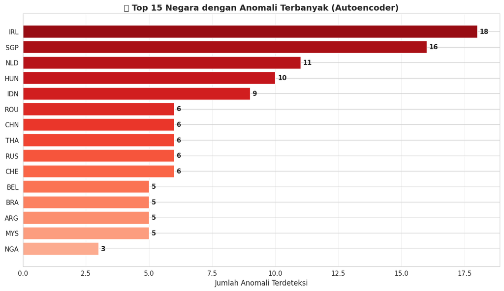

## 13. Analisis Bottleneck (Representasi Laten)

```
Shape representasi laten: (1714, 6)
Dimensi bottleneck: 6
```

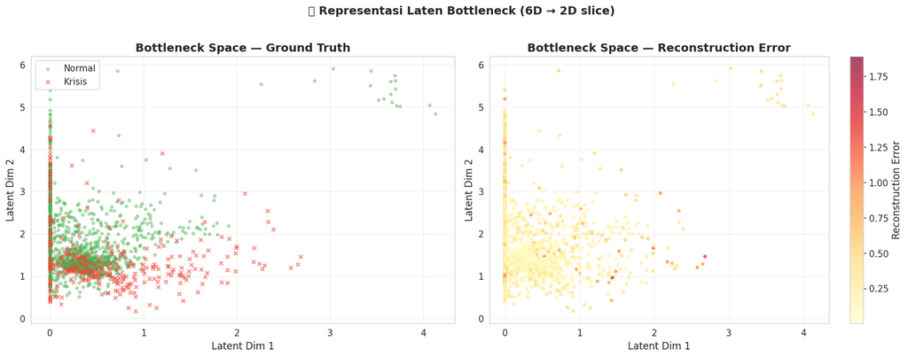

## 14. Ekspor Hasil

```
✅ Hasil deteksi disimpan ke: deka/hasil_autoencoder.csv
   Total baris  : 1714
   Anomali      : 138
   Kolom output : ['economy', 'year', 'GDP_Growth', 'GDP_PerCapita_Growth', 'Inflation_CPI', 'Total_Reserves', 'Unemployment', 'Current_Account_GDP', 'Trade_GDP', 'FDI_Inflows_GDP', 'Exports_GDP', 'Imports_GDP', 'Gross_Savings_GDP', 'Exchange_Rate', 'Manufacturing_Value', 'Investment_GDP', 'crisis_l…
```

## 15. Ringkasan Hasil

```
======================================================================
  🧠 RINGKASAN HASIL — AUTOENCODER ANOMALY DETECTION
  Early Warning System Krisis Ekonomi
======================================================================

  ┌─────────────────────────────────────────────────────────────┐
  │  DATASET                                                    │
  │  Observasi    : 1,714 (49 negara × 35 tahun)             │
  │  Fitur        : 14 indikator makroekonomi              │
  │  Ground Truth : 329 krisis (19.2%)                        │
  ├─────────────────────────────────────────────────────────────┤
  │  ARSITEKTUR AUTOENCODER                                     │
  │  Encoder      : 14 → 32 → 16 → 6 (bottleneck)            │
  │  Decoder      : 6 → 16 → 32 → 14 (output)                │
  │  Kompresi     : 2.3x (14D → 6D)                           │
  │  Loss         : MSE, Optimizer: Adam                        │
  │  Regularisasi : BatchNorm + Dropout(0.2) + EarlyStopping    │
  ├─────────────────────────────────────────────────────────────┤
  │  HASIL DETEKSI                                              │
  │  Threshold    : Persentil ke-92 = 0.453560            │
  │  Anomali      : 138 terdeteksi (8.1%)                     │
  ├─────────────────────────────────────────────────────────────┤
  │  EVALUASI vs GROUND TRUTH                                   │
  │  Precision    : 0.3261                                       │
  │  Recall       : 0.1368                                       │
  │  F1-Score     : 0.1927                                       │
  │  AUC-ROC      : 0.6066                                       │
  └─────────────────────────────────────────────────────────────┘

  📌 Top 3 Fitur Paling Sensitif terhadap Anomali:
     1. FDI_Inflows_GDP (Δ Error = 1.9294)
     2. GDP_PerCapita_Growth (Δ Error = 0.8396)
     3. GDP_Growth (Δ Error = 0.7285)

======================================================================
```